# BIOST 561: designing a simulation study for Bayes

Lecture 8

# Announcements

- In your a new GitHub issues in your `UWBiost561` package, I have assigned you two versions of `compute_maximal_partial_clique` to do a code-review of (for HW4 Question 1)
- We will go over HW4 in detail since it’s quite tricky
  - Unlike HW3 (which was hard because it involved coding a somewhat involved function), HW4 will be hard because it’s purposefully very open-ended and also involves you using Bayes (which you might be unfamilar with)
- I will also post the final project specifications this weekend

# How exactly is the server set up

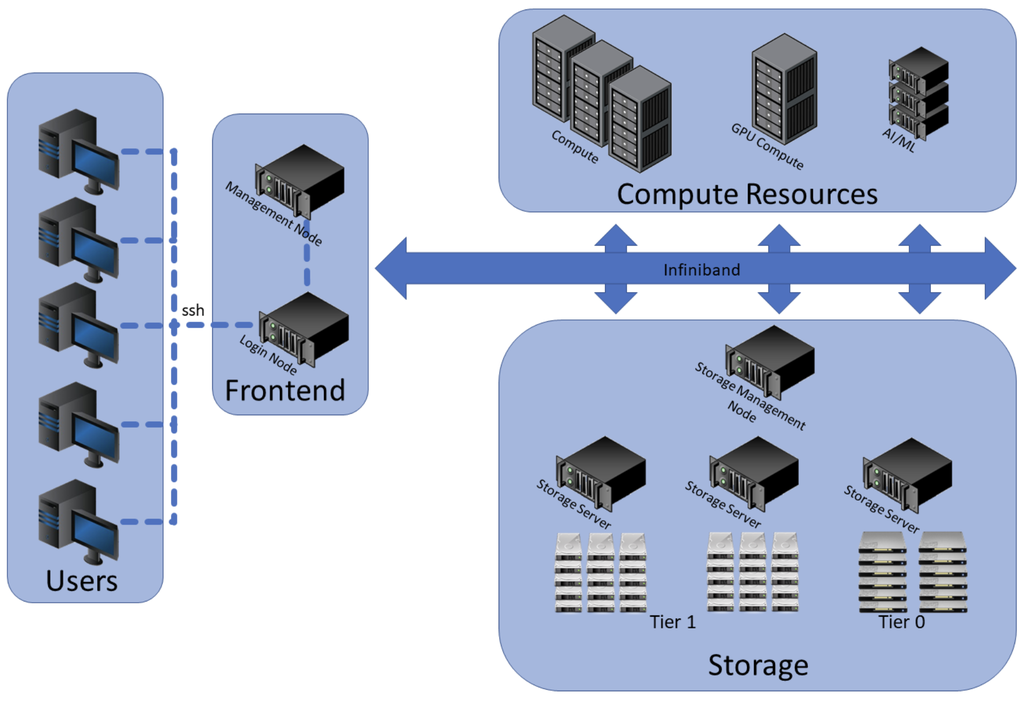

(Figure from https://www.marquette.edu/high-performance-computing/architecture.php)

# How exactly is the server set up

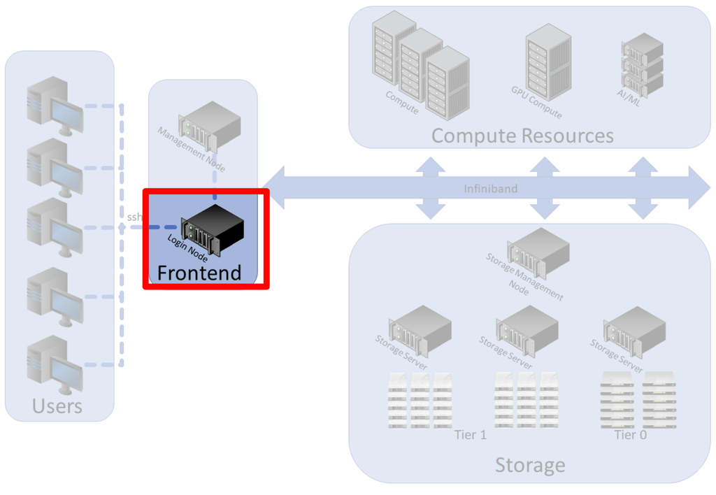

This node (highlighted in red) is the **shared** computing resoures you **all** are using when you log into Bayes.

- It doesn’t have a lot of computing power. You don’t have as much RAM compared to the compute node, and also you can’t parallelize your code much anyways
- It’s also a shared resources, so even if you’re crazy and run a big job on the login node, it’s at the detriment of everyone else who is simply trying to log into Bayes
- In conclusion, you should **not** use the login node for heavy jobs (i.e., loading in big data files, or performing calculations that take more a couple minutes to finish)
- The login node is ideal for:
  - Simple things for navigating and moving files/folders
  - Opening R to do quick calculations/plots (nothing too complicated – these should be things you would happy to do on your local laptop, but it’s just easier to do them on the server)

# More on server etiquette

We’ll talk about 2 most basic forms of etiquette

**One:** Checking the traffic on different partitions to know which partition to submit your job to.

- You can check the status of **all** the jobs on the server via `squeue` (instead of `squeue --me`)

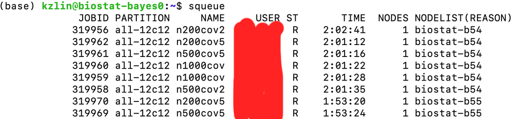

- (The usernames crossed out for anonymitiy, but remember, because the server is a public resource, everyone can see everyone else’s job being run.)
- The most common type of server drama I’ve seen if other departments is that one student hogs up all the nodes for multiple days in a row, and trust me, it gets really dramatic really fast. **Don’t let yourself be the source of the drama.**
  - If you’re parallelizing code, be mindful of how aggressively you parallelize it.
  - Realistically, a job that takes a couple hours to finish is alright. Submit your job, go get food, go on a break, or go to sleep, and then check your job status when you’re back.
  - This is why it’s incredibly important to test your code **before** you start your massive job. You don’t want to spend a couple hours to run your code, only for it to crash.
- You can also check the status of all the partitions you have access to via `sinfo`.

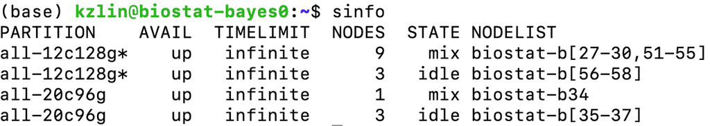

- A note about wording. Each “node” has many “cores” inside it. Your job takes up a complete “core” (which cannot be shared), but your job might be on the same node as another person’s job.
- Your screenshot will likely information about the student partition (which I, Kevin, do not have access to, and hence not shown when I run `sinfo`)

**Two:** Setting the amount of memory and time your job takes appropriately.

Recall these lines in `demo_bayes.slurm`:

```
#SBATCH --time=12:00:00
#SBATCH --mem-per-cpu=10gb
```

- The first line (`--time`) is (in hours:minutes:seconds) the maximum time your job is allotted. Typically, there’s no harm in keeping this 12 hours even if your job takes much less time
- The second line (`--mem-per-cpu`) is the real bottleneck. **Requesting more memory doet not make your job finish faster.** All this does is ensure your large datasets and results can fit in the R workspace.
  - More on how to determine what is a “reasonable” amount of space to allocate next week

# Onto making a simulation

- First discuss the workflow of how to create a simulation, save the results, and then load the results to make plots/print summary statistics, etc.
- Then, in-class,
  - download the R code you need for HW4
  - paste them into your `UWBiost561` packages
  - push your `UWBiost561` package from your laptop onto GitHub
  - pull them from GitHub onto Bayes
  - install your `UWBiost561` package on Bayes
  - run a simple demo script to make sure everything works

# Hmm… why are we even doing simulations?

- As you’ve experienced in all your other classes, for every problem, there are **tons and tons** of computational/statistical methods that researchers have developed over the decades
  - Everyone claims their method is the best (more on this in the last class)
  - **You**, however, should be a healthy skeptic – even if everyone were truthful, how do you know which method works the best for the specific problems **you** are trying to solve?

# Was is the ideal scenario for a simulation?

- You have some computational/statistical methods that you want to compare against
- Obviously, to make this a fair and meaningful comparison, you need to know:
  - 1. The ground truth
  - 2. A way to generate “randomness” (so you can assess if one method is doing better across **many** datasets, or just simply one dataset)
- Additionally, it’ll be nice if you have a “knob” to make your simulations “easier” or “harder”
  - You would hope all the methods you’re comparing against are “reasonable”, meaning they should all ace the easy setting.
  - However, you would hope as you make the problem harder and harder, certain methods rise to the occasion, and others start struggle (and this would make it clear to you which specific method you like)
- All these goals can be achieved in a simulation study

# What is a simulation study?

- A controlled way to measure how “good” different methods are
- This very simple statement is liced with a lot of assumptions to make it tangible:
  - Of course, **you** need to define what “good” means
  - To measure what “good” means, you probably need to know 1) what the “correct” answer is, and 2) how your method “guess/estimates” what an appropriate answer is based on data
  - To know how to define the “correct” answer despite the method seeing on noisy data, you need to also define a way to generate the data
- So there’s a lot of moving components. At mimimum there’s
  - A data generation mechanism
  - A few to many different methods (that take in data as input, and output results in a comparable format)
  - A way to measure how good/bad a method is

# The parts of simulation plan

- First: **What are you trying to study**
- Then: Define the different “levels” of your simulation. This is how you are changing the problem across the simulation. (This is the “knob” that controls how “easy/hard” the simulation is)
  - Have more and more variables? (About the data)
  - Have more and more samples? (About the data)
  - Have more and more noise? (About the data)
  - Have more and more complex relations between the variables? (About the data)
  - Have a grid of parameters for the methods? (About the method)
- Then: Define (based on your data generation mechanism) what you are trying to measure or what you’re trying to estimate. Make this as concrete as possible
- Then: Write down all the methods you are going to compare against
- Then: For each method, write down how you measure how “good/bad” each method is. This is an error metric that typically is based on the method’s outputs (and possibly, the data’s “correct answer”)
  - Note: Sometimes it’s hard to even know what the correct answer is. (Think of our partial cliques – it’s very easy to construct a graph with a partial clique, but sometimes, it’s not that easy to really know what is the largest partial clique)
- Then: write down how many trials you want in each level
  - The (Number of levels) x (Number of methods) x (Number of trials) is a simple way to determine how problem-instances our simulation has
- Finally: Think about the output of all these numbers. How are you going to manage these numbers? How will you plot the results?

# For the rest of class:

- Open up your laptops
- We’re going to:
  - download the R code you need for HW4
  - paste them into your `UWBiost561` packages
  - push your `UWBiost561` package from your laptop onto GitHub
  - pull them from GitHub onto Bayes
  - install your `UWBiost561` package on Bayes
  - run a simple demo script to make sure everything works
- We’ll then come back to the slides to talk about simulations
- Then, back on your laptop, we’ll:
  - run the demo of a simulation

# To check how much memory your job required

This yields the following output:

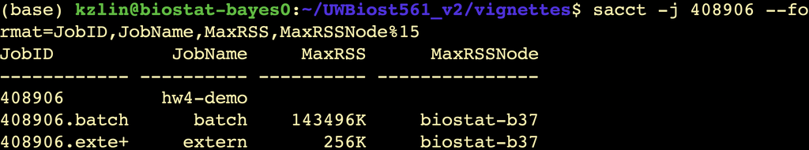

This job required 143496 Kilobytes (about 0.14 Gigabytes) to finish.

This number tells you how to appropriate adjust your memory usage in your SLURM script the next time you run it.

# Let’s take a look at the demo simulation I’ve given you

```
rm(list=ls())
set.seed(10)
library(UWBiost561)

imp_numbers <- 1:15
trials <- 5
alpha_vec <- c(0.5, 0.95)

# loop over the levels
level_trial_list <- lapply(alpha_vec, function(alpha){
  print(paste("Value of alpha:", alpha))

  # loop over the different trials for this level
  trial_list <- lapply(1:trials, function(trial){
    print(paste("Working on trial:", trial))
    # to freeze the randomness of adj_mat
    set.seed(trial)

    # generate the data
    data <- generate_partial_clique(n = 10)
    adj_mat <- data$adj_mat

    # loop over the methods for this trial
    result_list <- lapply(imp_numbers, function(imp_number){

      # to freeze the randomness of the method
      set.seed(trial)
      cat('*')
      result <- compute_maximal_partial_clique_master(
        adj_mat = adj_mat,
        alpha = alpha,
        number = imp_number,
        time_limit = 30
      )

      return(result)
    })
    names(result_list) <- paste("Implementation:", imp_numbers)
    cat("\n")

    return(result_list)
  })
  names(trial_list) <- paste("Trial:", 1:trials)
  print("====")

  return(trial_list)
})

names(level_trial_list) <- paste0("alpha:", alpha_vec)

# it's always useful to save the date and R session info
date_of_run <- Sys.time()
session_info <- devtools::session_info()

save(level_trial_list, # save your results
     alpha_vec,  # save which alphas you used
     date_of_run, session_info,
     file = "~/demo_simulation.RData")
```

- I’m abbreviating the code a bit so it’ll fit nicely on the slide

```
rm(list=ls())
set.seed(10)
library(UWBiost561)

imp_numbers <- 1:15
trials <- 5
alpha_vec <- c(0.5, 0.95)

# loop over the levels
level_trial_list <- lapply(alpha_vec, function(alpha){
  print(paste("Value of alpha:", alpha))

  # loop over the different trials for this level
  trial_list <- lapply(1:trials, function(trial){
    print(paste("Working on trial:", trial))
    # to freeze the randomness of adj_mat
    set.seed(trial)

    # generate the data
    data <- generate_partial_clique(n = 10)
    adj_mat <- data$adj_mat

    # loop over the methods for this trial
    result_list <- lapply(imp_numbers, function(imp_number){

      # to freeze the randomness of the method
      set.seed(trial)
      cat('*')
      result <- compute_maximal_partial_clique_master(
        adj_mat = adj_mat,
        alpha = alpha,
        number = imp_number,
        time_limit = 30
      )

      return(result)
    })
    names(result_list) <- paste("Implementation:", imp_numbers)
    cat("\n")

    return(result_list)
  })
  names(trial_list) <- paste("Trial:", 1:trials)
  print("====")

  return(trial_list)
})

names(level_trial_list) <- paste0("alpha:", alpha_vec)

# it's always useful to save the date and R session info
date_of_run <- Sys.time()
session_info <- devtools::session_info()

save(level_trial_list, # save your results
     alpha_vec,  # save which alphas you used
     date_of_run, session_info,
     file = "~/demo_simulation.RData")
```

- When you’re doing a simulation, it’s always good to clean the workspace, set the seed, and then load all the needed libraries
- This maximizes the chances your results are easily reproducible

```
rm(list=ls())
set.seed(10)
library(UWBiost561)

imp_numbers <- 1:15
trials <- 5
alpha_vec <- c(0.5, 0.95)

# loop over the levels
level_trial_list <- lapply(alpha_vec, function(alpha){
  print(paste("Value of alpha:", alpha))

  # loop over the different trials for this level
  trial_list <- lapply(1:trials, function(trial){
    print(paste("Working on trial:", trial))
    # to freeze the randomness of adj_mat
    set.seed(trial)

    # generate the data
    data <- generate_partial_clique(n = 10)
    adj_mat <- data$adj_mat

    # loop over the methods for this trial
    result_list <- lapply(imp_numbers, function(imp_number){

      # to freeze the randomness of the method
      set.seed(trial)
      cat('*')
      result <- compute_maximal_partial_clique_master(
        adj_mat = adj_mat,
        alpha = alpha,
        number = imp_number,
        time_limit = 30
      )

      return(result)
    })
    names(result_list) <- paste("Implementation:", imp_numbers)
    cat("\n")

    return(result_list)
  })
  names(trial_list) <- paste("Trial:", 1:trials)
  print("====")

  return(trial_list)
})

names(level_trial_list) <- paste0("alpha:", alpha_vec)

# it's always useful to save the date and R session info
date_of_run <- Sys.time()
session_info <- devtools::session_info()

save(level_trial_list, # save your results
     alpha_vec,  # save which alphas you used
     date_of_run, session_info,
     file = "~/demo_simulation.RData")
```

- This is where you declare:
- How many trials do you want per level (Here, keeping it simple, a fixed number of `5` per level)
- What are the levels? That is, what do you want to vary across the simulation study in terms of what you’re evaluating?
- The levels are sometimes about the data generating mechanism (i.e., more nodes in your graph). Here, it’s about the method arguments – we’re changing the required density of the partial clique, `alpha`

```
rm(list=ls())
set.seed(10)
library(UWBiost561)

imp_numbers <- 1:15
trials <- 5
alpha_vec <- c(0.5, 0.95)

# loop over the levels
level_trial_list <- lapply(alpha_vec, function(alpha){
  print(paste("Value of alpha:", alpha))

  # loop over the different trials for this level
  trial_list <- lapply(1:trials, function(trial){
    print(paste("Working on trial:", trial))
    # to freeze the randomness of adj_mat
    set.seed(trial)

    # generate the data
    data <- generate_partial_clique(n = 10)
    adj_mat <- data$adj_mat

    # loop over the methods for this trial
    result_list <- lapply(imp_numbers, function(imp_number){

      # to freeze the randomness of the method
      set.seed(trial)
      cat('*')
      result <- compute_maximal_partial_clique_master(
        adj_mat = adj_mat,
        alpha = alpha,
        number = imp_number,
        time_limit = 30
      )

      return(result)
    })
    names(result_list) <- paste("Implementation:", imp_numbers)
    cat("\n")

    return(result_list)
  })
  names(trial_list) <- paste("Trial:", 1:trials)
  print("====")

  return(trial_list)
})

names(level_trial_list) <- paste0("alpha:", alpha_vec)

# it's always useful to save the date and R session info
date_of_run <- Sys.time()
session_info <- devtools::session_info()

save(level_trial_list, # save your results
     alpha_vec,  # save which alphas you used
     date_of_run, session_info,
     file = "~/demo_simulation.RData")
```

- First and foremost, we need to loop over **levels** (here, the `alpha` values)
- We’re using an `lapply()` since we want to output a list where each element of the list is the all the results for one value of `alpha`

```
rm(list=ls())
set.seed(10)
library(UWBiost561)

imp_numbers <- 1:15
trials <- 5
alpha_vec <- c(0.5, 0.95)

# loop over the levels
level_trial_list <- lapply(alpha_vec, function(alpha){
  print(paste("Value of alpha:", alpha))

  # loop over the different trials for this level
  trial_list <- lapply(1:trials, function(trial){
    print(paste("Working on trial:", trial))
    # to freeze the randomness of adj_mat
    set.seed(trial)

    # generate the data
    data <- generate_partial_clique(n = 10)
    adj_mat <- data$adj_mat

    # loop over the methods for this trial
    result_list <- lapply(imp_numbers, function(imp_number){

      # to freeze the randomness of the method
      set.seed(trial)
      cat('*')
      result <- compute_maximal_partial_clique_master(
        adj_mat = adj_mat,
        alpha = alpha,
        number = imp_number,
        time_limit = 30
      )

      return(result)
    })
    names(result_list) <- paste("Implementation:", imp_numbers)
    cat("\n")

    return(result_list)
  })
  names(trial_list) <- paste("Trial:", 1:trials)
  print("====")

  return(trial_list)
})

names(level_trial_list) <- paste0("alpha:", alpha_vec)

# it's always useful to save the date and R session info
date_of_run <- Sys.time()
session_info <- devtools::session_info()

save(level_trial_list, # save your results
     alpha_vec,  # save which alphas you used
     date_of_run, session_info,
     file = "~/demo_simulation.RData")
```

- Next, we want to loop over the **trials**
- This is yet another `lapply()`. This is the “middle” list.
- Usually, in a simulation study, the “trials” refer to “different instances of generating random data for the same parameter setting”
- Loosely speaking, each dataset in the the same trial should be of “equal difficulty”, but in a literal sense, are all slightly different (because the data generation mechanism is random)

```
rm(list=ls())
set.seed(10)
library(UWBiost561)

imp_numbers <- 1:15
trials <- 5
alpha_vec <- c(0.5, 0.95)

# loop over the levels
level_trial_list <- lapply(alpha_vec, function(alpha){
  print(paste("Value of alpha:", alpha))

  # loop over the different trials for this level
  trial_list <- lapply(1:trials, function(trial){
    print(paste("Working on trial:", trial))
    # to freeze the randomness of adj_mat
    set.seed(trial)

    # generate the data
    data <- generate_partial_clique(n = 10)
    adj_mat <- data$adj_mat

    # loop over the methods for this trial
    result_list <- lapply(imp_numbers, function(imp_number){

      # to freeze the randomness of the method
      set.seed(trial)
      cat('*')
      result <- compute_maximal_partial_clique_master(
        adj_mat = adj_mat,
        alpha = alpha,
        number = imp_number,
        time_limit = 30
      )

      return(result)
    })
    names(result_list) <- paste("Implementation:", imp_numbers)
    cat("\n")

    return(result_list)
  })
  names(trial_list) <- paste("Trial:", 1:trials)
  print("====")

  return(trial_list)
})

names(level_trial_list) <- paste0("alpha:", alpha_vec)

# it's always useful to save the date and R session info
date_of_run <- Sys.time()
session_info <- devtools::session_info()

save(level_trial_list, # save your results
     alpha_vec,  # save which alphas you used
     date_of_run, session_info,
     file = "~/demo_simulation.RData")
```

- Within a trial, you want to generate **one** dataset
- Every method will be evaluated on this one dataset

```
rm(list=ls())
set.seed(10)
library(UWBiost561)

imp_numbers <- 1:15
trials <- 5
alpha_vec <- c(0.5, 0.95)

# loop over the levels
level_trial_list <- lapply(alpha_vec, function(alpha){
  print(paste("Value of alpha:", alpha))

  # loop over the different trials for this level
  trial_list <- lapply(1:trials, function(trial){
    print(paste("Working on trial:", trial))
    # to freeze the randomness of adj_mat
    set.seed(trial)

    # generate the data
    data <- generate_partial_clique(n = 10)
    adj_mat <- data$adj_mat

    # loop over the methods for this trial
    result_list <- lapply(imp_numbers, function(imp_number){

      # to freeze the randomness of the method
      set.seed(trial)
      cat('*')
      result <- compute_maximal_partial_clique_master(
        adj_mat = adj_mat,
        alpha = alpha,
        number = imp_number,
        time_limit = 30
      )

      return(result)
    })
    names(result_list) <- paste("Implementation:", imp_numbers)
    cat("\n")

    return(result_list)
  })
  names(trial_list) <- paste("Trial:", 1:trials)
  print("====")

  return(trial_list)
})

names(level_trial_list) <- paste0("alpha:", alpha_vec)

# it's always useful to save the date and R session info
date_of_run <- Sys.time()
session_info <- devtools::session_info()

save(level_trial_list, # save your results
     alpha_vec,  # save which alphas you used
     date_of_run, session_info,
     file = "~/demo_simulation.RData")
```

- Be sure the use `set.seed()` when generating the data. (This will make it easy for you to reproduce the data for a specific data, so your simulation doesn’t need to actually store the data itself)
- Typically, you want to design a data generation mechanism where it’s fast to generate data, but might take a while to use the method on the data

```
rm(list=ls())
set.seed(10)
library(UWBiost561)

imp_numbers <- 1:15
trials <- 5
alpha_vec <- c(0.5, 0.95)

# loop over the levels
level_trial_list <- lapply(alpha_vec, function(alpha){
  print(paste("Value of alpha:", alpha))

  # loop over the different trials for this level
  trial_list <- lapply(1:trials, function(trial){
    print(paste("Working on trial:", trial))
    # to freeze the randomness of adj_mat
    set.seed(trial)

    # generate the data
    data <- generate_partial_clique(n = 10)
    adj_mat <- data$adj_mat

    # loop over the methods for this trial
    result_list <- lapply(imp_numbers, function(imp_number){

      # to freeze the randomness of the method
      set.seed(trial)
      cat('*')
      result <- compute_maximal_partial_clique_master(
        adj_mat = adj_mat,
        alpha = alpha,
        number = imp_number,
        time_limit = 30
      )

      return(result)
    })
    names(result_list) <- paste("Implementation:", imp_numbers)
    cat("\n")

    return(result_list)
  })
  names(trial_list) <- paste("Trial:", 1:trials)
  print("====")

  return(trial_list)
})

names(level_trial_list) <- paste0("alpha:", alpha_vec)

# it's always useful to save the date and R session info
date_of_run <- Sys.time()
session_info <- devtools::session_info()

save(level_trial_list, # save your results
     alpha_vec,  # save which alphas you used
     date_of_run, session_info,
     file = "~/demo_simulation.RData")
```

- Now you want to loop over your **methods**. This is the inner-most list.
- Therefore, our output is actually 3 nested lists
- It goes “levels” into “trials” into “methods”

```
rm(list=ls())
set.seed(10)
library(UWBiost561)

imp_numbers <- 1:15
trials <- 5
alpha_vec <- c(0.5, 0.95)

# loop over the levels
level_trial_list <- lapply(alpha_vec, function(alpha){
  print(paste("Value of alpha:", alpha))

  # loop over the different trials for this level
  trial_list <- lapply(1:trials, function(trial){
    print(paste("Working on trial:", trial))
    # to freeze the randomness of adj_mat
    set.seed(trial)

    # generate the data
    data <- generate_partial_clique(n = 10)
    adj_mat <- data$adj_mat

    # loop over the methods for this trial
    result_list <- lapply(imp_numbers, function(imp_number){

      # to freeze the randomness of the method
      set.seed(trial)
      cat('*')
      result <- compute_maximal_partial_clique_master(
        adj_mat = adj_mat,
        alpha = alpha,
        number = imp_number,
        time_limit = 30
      )

      return(result)
    })
    names(result_list) <- paste("Implementation:", imp_numbers)
    cat("\n")

    return(result_list)
  })
  names(trial_list) <- paste("Trial:", 1:trials)
  print("====")

  return(trial_list)
})

names(level_trial_list) <- paste0("alpha:", alpha_vec)

# it's always useful to save the date and R session info
date_of_run <- Sys.time()
session_info <- devtools::session_info()

save(level_trial_list, # save your results
     alpha_vec,  # save which alphas you used
     date_of_run, session_info,
     file = "~/demo_simulation.RData")
```

- Here is where we run all 15 different methods
- Remeber that `imp_numbers` is 1 through 15, and we’re using `number=imp_number` inside the `lapply()`.
- Hence, `result_list` is a list of results. It will have length 15, where each element of the list is the result of one of the 15 implementation of `compute_maximal_partial_clique`
- Sidenote: It’s **very** useful to have **one** “master” function that deploys all the different implementations. This makes your simulation much easier to read
  - In this homework, I made `compute_maximal_partial_clique_master()` for you, but when you write your own simulation study beyond this course, you might want to do something similar
  - This `compute_maximal_partial_clique_master()` also helps to ensure that all the methods provide an output in the same format
  - Remember, the result of any `compute_maximal_partial_clique` implementation is a list itself!

```
rm(list=ls())
set.seed(10)
library(UWBiost561)

imp_numbers <- 1:15
trials <- 5
alpha_vec <- c(0.5, 0.95)

# loop over the levels
level_trial_list <- lapply(alpha_vec, function(alpha){
  print(paste("Value of alpha:", alpha))

  # loop over the different trials for this level
  trial_list <- lapply(1:trials, function(trial){
    print(paste("Working on trial:", trial))
    # to freeze the randomness of adj_mat
    set.seed(trial)

    # generate the data
    data <- generate_partial_clique(n = 10)
    adj_mat <- data$adj_mat

    # loop over the methods for this trial
    result_list <- lapply(imp_numbers, function(imp_number){

      # to freeze the randomness of the method
      set.seed(trial)
      cat('*')
      result <- compute_maximal_partial_clique_master(
        adj_mat = adj_mat,
        alpha = alpha,
        number = imp_number,
        time_limit = 30
      )

      return(result)
    })
    names(result_list) <- paste("Implementation:", imp_numbers)
    cat("\n")

    return(result_list)
  })
  names(trial_list) <- paste("Trial:", 1:trials)
  print("====")

  return(trial_list)
})

names(level_trial_list) <- paste0("alpha:", alpha_vec)

# it's always useful to save the date and R session info
date_of_run <- Sys.time()
session_info <- devtools::session_info()

save(level_trial_list, # save your results
     alpha_vec,  # save which alphas you used
     date_of_run, session_info,
     file = "~/demo_simulation.RData")
```

- It’s useful to set the seed again right before each method, since you don’t know if certain methods use any randomness or not

```
rm(list=ls())
set.seed(10)
library(UWBiost561)

imp_numbers <- 1:15
trials <- 5
alpha_vec <- c(0.5, 0.95)

# loop over the levels
level_trial_list <- lapply(alpha_vec, function(alpha){
  print(paste("Value of alpha:", alpha))

  # loop over the different trials for this level
  trial_list <- lapply(1:trials, function(trial){
    print(paste("Working on trial:", trial))
    # to freeze the randomness of adj_mat
    set.seed(trial)

    # generate the data
    data <- generate_partial_clique(n = 10)
    adj_mat <- data$adj_mat

    # loop over the methods for this trial
    result_list <- lapply(imp_numbers, function(imp_number){

      # to freeze the randomness of the method
      set.seed(trial)
      cat('*')
      result <- compute_maximal_partial_clique_master(
        adj_mat = adj_mat,
        alpha = alpha,
        number = imp_number,
        time_limit = 30
      )

      return(result)
    })
    names(result_list) <- paste("Implementation:", imp_numbers)
    cat("\n")

    return(result_list)
  })
  names(trial_list) <- paste("Trial:", 1:trials)
  print("====")

  return(trial_list)
})

names(level_trial_list) <- paste0("alpha:", alpha_vec)

# it's always useful to save the date and R session info
date_of_run <- Sys.time()
session_info <- devtools::session_info()

save(level_trial_list, # save your results
     alpha_vec,  # save which alphas you used
     date_of_run, session_info,
     file = "~/demo_simulation.RData")
```

- Because we have soooooo many nested lists, it’s useful to name each element of the list appropriate so you know what you’re looking at when you load the results later on

```
rm(list=ls())
set.seed(10)
library(UWBiost561)

imp_numbers <- 1:15
trials <- 5
alpha_vec <- c(0.5, 0.95)

# loop over the levels
level_trial_list <- lapply(alpha_vec, function(alpha){
  print(paste("Value of alpha:", alpha))

  # loop over the different trials for this level
  trial_list <- lapply(1:trials, function(trial){
    print(paste("Working on trial:", trial))
    # to freeze the randomness of adj_mat
    set.seed(trial)

    # generate the data
    data <- generate_partial_clique(n = 10)
    adj_mat <- data$adj_mat

    # loop over the methods for this trial
    result_list <- lapply(imp_numbers, function(imp_number){

      # to freeze the randomness of the method
      set.seed(trial)
      cat('*')
      result <- compute_maximal_partial_clique_master(
        adj_mat = adj_mat,
        alpha = alpha,
        number = imp_number,
        time_limit = 30
      )

      return(result)
    })
    names(result_list) <- paste("Implementation:", imp_numbers)
    cat("\n")

    return(result_list)
  })
  names(trial_list) <- paste("Trial:", 1:trials)
  print("====")

  return(trial_list)
})

names(level_trial_list) <- paste0("alpha:", alpha_vec)

# it's always useful to save the date and R session info
date_of_run <- Sys.time()
session_info <- devtools::session_info()

save(level_trial_list, # save your results
     alpha_vec,  # save which alphas you used
     date_of_run, session_info,
     file = "~/demo_simulation.RData")
```

- Printing out things is useful so you (when you check on your `.Rout` file) can gauge how far along your simulation is

```
rm(list=ls())
set.seed(10)
library(UWBiost561)

imp_numbers <- 1:15
trials <- 5
alpha_vec <- c(0.5, 0.95)

# loop over the levels
level_trial_list <- lapply(alpha_vec, function(alpha){
  print(paste("Value of alpha:", alpha))

  # loop over the different trials for this level
  trial_list <- lapply(1:trials, function(trial){
    print(paste("Working on trial:", trial))
    # to freeze the randomness of adj_mat
    set.seed(trial)

    # generate the data
    data <- generate_partial_clique(n = 10)
    adj_mat <- data$adj_mat

    # loop over the methods for this trial
    result_list <- lapply(imp_numbers, function(imp_number){

      # to freeze the randomness of the method
      set.seed(trial)
      cat('*')
      result <- compute_maximal_partial_clique_master(
        adj_mat = adj_mat,
        alpha = alpha,
        number = imp_number,
        time_limit = 30
      )

      return(result)
    })
    names(result_list) <- paste("Implementation:", imp_numbers)
    cat("\n")

    return(result_list)
  })
  names(trial_list) <- paste("Trial:", 1:trials)
  print("====")

  return(trial_list)
})

names(level_trial_list) <- paste0("alpha:", alpha_vec)

# it's always useful to save the date and R session info
date_of_run <- Sys.time()
session_info <- devtools::session_info()

save(level_trial_list, # save your results
     alpha_vec,  # save which alphas you used
     date_of_run, session_info,
     file = "~/demo_simulation.RData")
```

- Now save your results!
- I find it useful to save the current time and the R session info (just in case I need to double check which version of certain packages were used)
- The two important things you want to save are: your simulation results (here, `level_trial_list`) and what the values of the different levels were (here, `alpha_vec`)
- (You would load these results in, just like any other R data object, and then analyze all your results, make plots, etc.)

# How to think about a (generic) simulation output

Here’s how to think about the simulation output

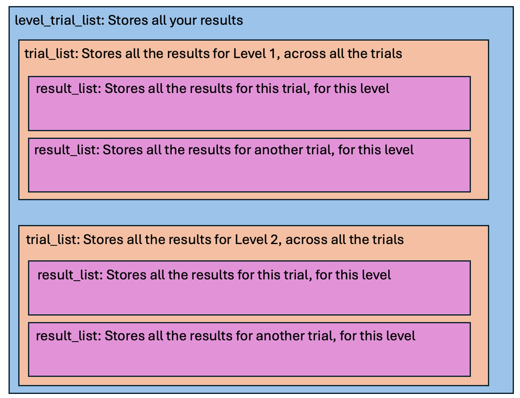

# With the remaining time…

- Run the demo of a simulation
- See how to make a simple plot of the demo results, and get that plot from Bayes back onto your laptop (via GitHub)
- Discussing the vision of HW4
- Looking ahead:
  - Lecture 9 will be about Pkgdown and Github.io (your personal websites). We’ll also talk more about designing simulations.
  - Lecture 10 (last class) is a catch-all. We will discuss a bit about your simulation results in HW4, a bit about Python, and a bit about ChatGPT

# Additional links

- Companion Google Docs for Linux commands and using Bayes
  - https://docs.google.com/document/d/1-ZTDPp39zbhsKbQ2FfBoCtiXKQj0jQSg75MAatYfiGI/edit?usp=sharing
  - I’ll be adding more content to this, even after I post HW4
- Debugging
  - https://adv-r.hadley.nz/debugging.html
- Cheatsheet for Git commands
  - https://education.github.com/git-cheat-sheet-education.pdf
- Cheatsheet for Linux commands
  - https://phoenixnap.com/kb/wp-content/uploads/2023/11/linux-commands-cheat-sheet-pdf.pdf
  - The most useful commands are the ones under “Directory Navigation” and Files”
- Cheatsheat for SLURM commands
  - https://www.carc.usc.edu/user-information/user-guides/hpc-basics/slurm-cheatsheet